# Image Features

This notebook provides a guide on how to extract features from an image. The features that are currently implemented are:

1. **HOG**
2. **IGO**
3. **ES**
4. **LBP**

It also shows in Section 5 that features can be combined.

Firstly, let's import the needed packages

```python
import matplotlib.pyplot as plt
import menpo.io as mio
```

and load and plot an input image

```
403W x 411H 2D mask, 58.9% of which is True
```

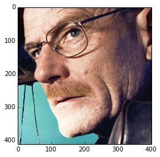

```python
%matplotlib inline
breaking_bad = mio.import_builtin_asset('breakingbad.jpg')
breaking_bad.crop_to_landmarks(boundary=20)
breaking_bad.constrain_mask_to_landmarks()
breaking_bad.view(masked=False);
print(breaking_bad.mask)
```

The input image is annotated

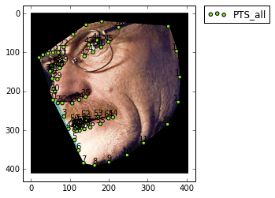

```python
breaking_bad.landmarks.view();
```

and has 3 channels (RGB)

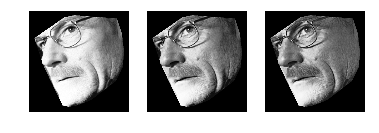

```python
breaking_bad.view(channels='all');
```

# 1. HOG Features

The HOG (Histogram of Oriented Gradients) features method clusters gradient orientations in different bins for localized sub-windows of the input image, resulting in counting occurences of the orientations. One can extract *dense* HOGs with control over the density and *sparse* which refer to the original HOGs formulation.

### 1.1 Dense HOGs

This is an example of dense HOGs with sampling step of 3 pixels horizontally and vertically. In this example, we include all the possible HOG parameters.

```python
%%time
hog = breaking_bad.features.hog(mode='dense',
                                algorithm='dalaltriggs',
                                cell_size=8,
                                block_size=2,
                                num_bins=9,
                                signed_gradient=True,
                                l2_norm_clip=0.2,
                                window_height=1, window_width=1, window_unit='blocks',
                                window_step_vertical=3, window_step_horizontal=3, window_step_unit='pixels',
                                padding=True,
                                verbose=True,
                                constrain_landmarks=True)
```

```
Window Iterator:
  - Input image is 403W x 411H with 3 channels.
  - Window of size 16W x 16H and step (3W,3H).
  - Padding is enabled.
  - Number of windows is 135W x 137H.
HOG features:
  - Algorithm of Dalal & Triggs.
  - Cell is 8x8 pixels.
  - Block is 2x2 cells.
  - 9 orientation bins and signed angles.
  - L2-norm clipped at 0.2.
  - Number of blocks per window = 1W x 1H.
  - Descriptor length per window = 1W x 1H x 36 = 36 x 1.
Output image size 135W x 137H x 36.
CPU times: user 432 ms, sys: 3.49 ms, total: 435 ms
Wall time: 434 ms
```

Visualize with and without landmarks and either in glyph or image mode:

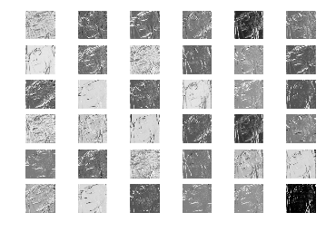

```python
hog.view(masked=False);
```

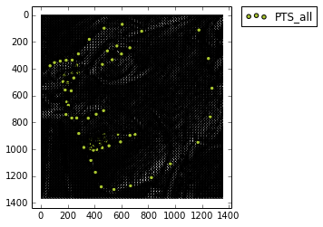

```python
hog.glyph().landmarks.view();
```

I prefer this visualization technique

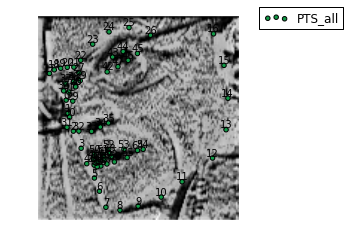

```python
hog.glyph(vectors_block_size=1,).landmarks.view(channels='all');
```

### 1.2 Sparse HOGs

Setting the *mode* option to *sparse* returns the original sparsely-sampled HOGs

```
Window Iterator:
  - Input image is 403W x 411H with 3 channels.
  - Window of size 24W x 24H and step (8W,8H).
  - Padding is disabled.
  - Number of windows is 48W x 49H.
HOG features:
  - Algorithm of Zhu & Ramanan.
  - Cell is 8x8 pixels.
  - Block is 2x2 cells.
  - Number of blocks per window = 1W x 1H.
  - Descriptor length per window = 1W x 1H x 31 = 31 x 1.
Output image size 48W x 49H x 31.
CPU times: user 117 ms, sys: 1.55 ms, total: 118 ms
Wall time: 117 ms
```

[figure not shown]

```python
%%time
hog = breaking_bad.features.hog(mode='sparse',
                                algorithm='zhuramanan',
                                verbose=True)
hog.glyph(vectors_block_size=4).view();
```

and with landmarks:

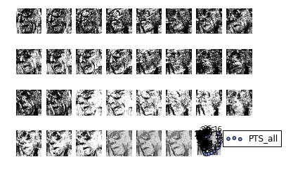

```python
hog.landmarks.view(masked=False);
```

### 1.3 Default Options

The extraction of HOG features with the default options

```python
%%time
hog = breaking_bad.features.hog()
```

```
CPU times: user 3.54 s, sys: 41.5 ms, total: 3.58 s
Wall time: 3.59 s
```

returns the most densely-sampled HOG version and is of course very slow...

```python
print(hog)
```

```
403W x 411H 2D MaskedImage with 36 channels. Attached mask 58.9% true
```

They return a HOG image with the same width and height as the input image.

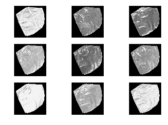

```python
hog.view(channels=range(9));
```

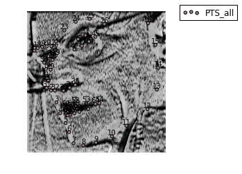

```python
hog.glyph(vectors_block_size=1).landmarks.view(channels='all');
```

### 1.4 Constrain Landmarks

In some cases, depending on the options given by the user, the landmarks may end up outside of the bounds of the features image. By enabling the flag *constrain_landmarks*, the landmarks that lie outside the borders will be constrained to the image bounds. The default value is `constrain_landmarks=True`. This applies in all features categories. For example:

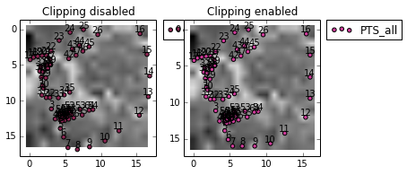

```python
# clipping disabled
plt.subplot(121); plt.title('Clipping disabled')
breaking_bad.resize([150, 150]).features.hog(mode='sparse',constrain_landmarks=False).landmarks.view(channels=1,masked=False)
# clipping enabled
plt.subplot(122); plt.title('Clipping enabled')
breaking_bad.resize([150, 150]).features.hog(mode='sparse').landmarks.view(channels=1,masked=False)
```

### 1.5 Windows Centres

All feature types return a matrix with the coordinates of the windows centers on which they were computed:

```python
hog = breaking_bad.features.hog(mode='sparse')
print(hog.pixels.shape)
print(hog.window_centres.shape)
```

```
(50, 49, 36)
(50, 49, 2)
```

# 2. IGO Features

The IGO (Image Gradient Orientations) features concatenate the *cos()* and *sin()* of the gradient orientation angles at each image pixel. The *cos()* and *sin()* can be computed either on the actual orientation angles or to both the initial and double value of the angles.

### 2.1 Single angles

Here is an example of such computation, which is set to be the default:

```python
%%time
igo_single = breaking_bad.features.igo()
```

```
CPU times: user 52.4 ms, sys: 18.4 ms, total: 70.9 ms
Wall time: 70.1 ms
```

```python
print(igo_single)
```

```
403W x 411H 2D MaskedImage with 6 channels. Attached mask 58.9% true
```

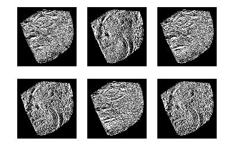

```python
igo_single.view(channels='all');
```

or

[figure not shown]

```python
igo_single.glyph().view(channels='all');
```

### 2.2 Double angles

This is an example by enabling the `double_angles` flag. This is the only parameter that is related to the IGO computation.

```python
%%time
igo = breaking_bad.features.igo(double_angles=True, verbose=True)
```

```
IGO Features:
  - Input image is 403W x 411H with 3 channels.
  - Double angles are enabled.
Output image size 403W x 411H x 12.
CPU times: user 76.7 ms, sys: 44 ms, total: 121 ms
Wall time: 120 ms
```

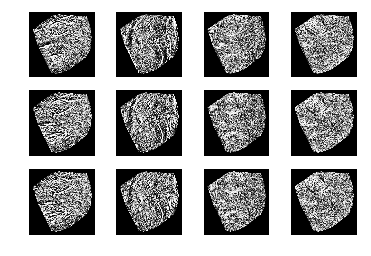

```python
igo.view(channels='all');
```

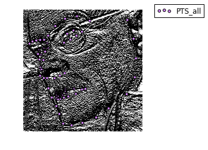

```python
igo.glyph(vectors_block_size=1).landmarks.view(channels='all');
```

# 3. ES Features

ES (Edge Structure) features provide a measure which captures the orientation of image structure at each pixel, together with an indication of how accurate the orientation estimate is. The accuracy belief measure penalizes the orientations in flat, noisy regions and favours the ones near strong edges. Here is an example:

```python
%%time
es = breaking_bad.features.es(verbose=True)
```

```
ES Features:
  - Input image is 403W x 411H with 3 channels.
Output image size 403W x 411H x 6.
CPU times: user 35.7 ms, sys: 13.4 ms, total: 49.1 ms
Wall time: 48.6 ms
```

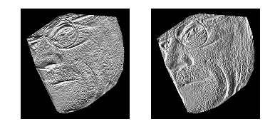

```python
es.view(channels=[0, 1]);
```

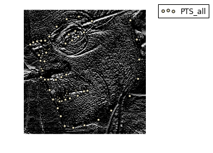

```python
es.glyph(vectors_block_size=1).landmarks.view(channels='all');
```

# 4. LBP Features

The basic idea behind LBP (Local Binary Patterns) features is to encode the local structure in an image by comparing each pixel’s intensity value with its neighborhood and then assign an appropriate code. The user can control their density through the `window_step_vertical` and `window_step_horizontal` parameters. At each pixel, the LBP code is computed on circle(s) with radius (radii) defined in `radius`. For each `radius` value, the user has to define the respective number of sampling points, using the parameter `samples`. The parameter `mapping_type` defines the LBP codes mapping: *uniform-2*, *rotation-invariant* or *uniform-2 and rotation_invariant*.

In this example, we extract quite dense LBP features using two *radius/samples* combinations. The example also includes all the possible parameters.

```python
%%time
lbp = breaking_bad.features.lbp(radius=[3, 4],
                                samples=[10, 12],
                                mapping_type='ri',
                                window_step_vertical=1,
                                window_step_horizontal=1,
                                window_step_unit='pixels',
                                padding=True,
                                verbose=True,
                                constrain_landmarks=True)
```

```
Window Iterator:
  - Input image is 403W x 411H with 3 channels.
  - Window of size 9W x 9H and step (1W,1H).
  - Padding is enabled.
  - Number of windows is 403W x 411H.
LBP features:
  - 2 combinations of radii and samples.
  - Radii values: [3, 4].
  - Samples values: [10, 12].
  - Rotation-Invariant codes mapping.
  - Descriptor length per window = 6 x 1.
Output image size 403W x 411H x 6.
CPU times: user 329 ms, sys: 5.19 ms, total: 334 ms
Wall time: 334 ms
```

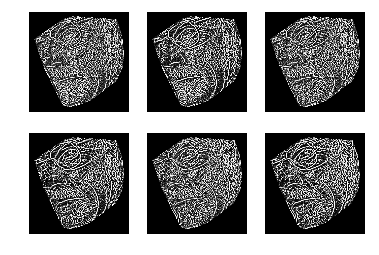

```python
lbp.view(channels='all');
```

Here is an example with the default values:

```python
%%time
lbp = breaking_bad.features.lbp()
```

```
CPU times: user 415 ms, sys: 13.3 ms, total: 429 ms
Wall time: 428 ms
```

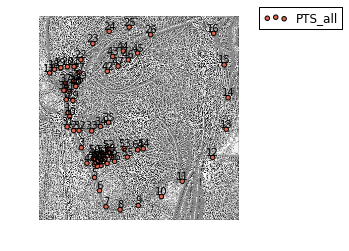

```python
lbp.glyph(vectors_block_size=1).landmarks.view(channels='all');
```

Note that all implemented features hold the parameters' values given by the user:

```python
print lbp.lbp_parameters
```

```
{'window_step_unit': 'pixels', 'padding': True, 'window_step_horizontal': 1, 'radius': [1, 2, 3, 4], 'mapping_type': 'riu2', 'samples': [8, 8, 8, 8], 'original_image_height': 411, 'original_image_width': 403, 'window_step_vertical': 1, 'original_image_channels': 3}
```

### 4.1 LBP Codes Histogram

LBPs are ideal to be used as image descriptors. This is achieved by binning the codes of the output image, as follows:

```python
hist, bin_edges = breaking_bad.as_greyscale().features.lbp(radius=1, samples=8).as_histogram()
```

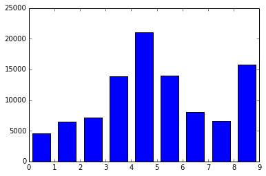

```python
width = 0.7 * (bin_edges[1] - bin_edges[0])
center = (bin_edges[:-1] + bin_edges[1:]) / 2
plt.bar(center, hist, align='center', width=width);
```

# 5. Features Combination

The user is able to extract features from a features image (if that makes any sense!). For example we can compute the LBP features of the IGO-based image:

```python
%%time
lbp_igo = breaking_bad.as_greyscale().features.igo(verbose=True).features.lbp(radius=2, samples=8, mapping_type='none', verbose=True)
```

```
IGO Features:
  - Input image is 403W x 411H with 1 channels.
  - Double angles are disabled.
Output image size 403W x 411H x 2.
Window Iterator:
  - Input image is 403W x 411H with 2 channels.
  - Window of size 5W x 5H and step (1W,1H).
  - Padding is enabled.
  - Number of windows is 403W x 411H.
LBP features:
  - 1 combination of radius and samples.
  - Radius value: 2.
  - Samples value: 8.
  - No codes mapping used.
  - Descriptor length per window = 2 x 1.
Output image size 403W x 411H x 2.
CPU times: user 108 ms, sys: 3.38 ms, total: 112 ms
Wall time: 111 ms
```

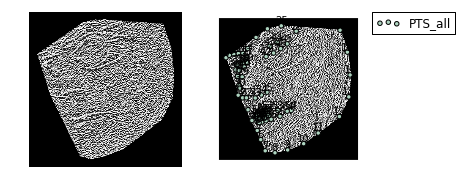

```python
lbp_igo.landmarks.view(channels='all');
```